# Introduction to R

Claas Heuer

2023-05-06

# Get R

[From CRAN](https://cran.r-project.org/)

[Rstudio](https://www.rstudio.com/products/rstudio/download/#download)

Ubuntu: `sudo apt install r-base`

# Some Introduction Material

From the developers: [Introduction to R](https://cran.r-project.org/doc/manuals/r-release/R-intro.pdf)

Rstudio: [Documentation](https://docs.rstudio.com/)

[R for Data Science](https://r4ds.had.co.nz/introduction.html)

# Background

- R is a general programming language with a specialization for statistics
- R is generally being used through a [REPL](https://en.wikipedia.org/wiki/Read%E2%80%93eval%E2%80%93print_loop) and interpreted live
- Functional Programming paradigm: All about `objects` and `functions`
- Major Appeals:
  - Extremely large ecosystem of packages, contributors, support system and companies
  - Many general and special solutions already available in R
  - Easy to learn and get going
  - Amongst the best graphics/plotting ecosystem for scientific output
- Major Drawbacks:
  - Functional Programming lends itself to “scripting” without structure
  - Barrier for introducing structure through packages high
  - R is an interpreted and not compiled language: no optimization
  - “Always copy paradigm” makes R slow in many settings
  - R is old and its [successors](https://julialang.org/) already exist

# Basics

## Assigning and manipulating variables

Note: R has 2 assignment operator: `<-` and `=`. For all relevant porpuses of the tutorial, we can safely use either of those operators interchably.

```r
############################################
### Assigning and manipulating variables ###
############################################

x = 5
print(x)
```

```
## [1] 5
```

```r
# just givng the variable name, will print it to the REPL by default
x
```

```
## [1] 5
```

```r
# assign value from one variable to the next
y = x

# object did not trigger a copy of "x", rather y "points" to x
print(y)
```

```
## [1] 5
```

```r
# change the value of x
x = 3

print(x)
```

```
## [1] 3
```

```r
# at the moment we changed the value of "x", a copy of the old "x" was triggered and assigned to "y"
print(y)
```

```
## [1] 5
```

## Working with data frames

One of the most important object types in R are `data.frames`. They are rectangular tables with rows and columns, whereas the column can have different `types`, which is the main differntiator to a `matrix`, where the column types are all identical.

```r
############################################
### Assigning and manipulating variables ###
############################################

dat = data.frame(
         name = c("Adam", "Paul", "Elly"),
         age = c(22, 43, 54)
         )

# look at general structure
str(x)
```

```
##  num 3
```

```r
# extracting single column and storing in a vector object
names = dat$name

# can also be accessed with the bracket operator
ages = dat[, "age"]

str(names)
```

```
##  chr [1:3] "Adam" "Paul" "Elly"
```

```r
str(ages)
```

```
##  num [1:3] 22 43 54
```

```r
# subsetting
dat[dat$name == "Paul",]
```

```
##   name age
## 2 Paul  43
```

```r
dat[dat$age %in% c(22, 54),]
```

```
##   name age
## 1 Adam  22
## 3 Elly  54
```

```r
# adding a column to a data frame
dat$id = 1:nrow(dat)
dat[, "id_2"] = dat$id + 2

print(dat)
```

```
##   name age id id_2
## 1 Adam  22  1    3
## 2 Paul  43  2    4
## 3 Elly  54  3    5
```

```r
# conditional assignment
dat$id[dat$name == "Adam"] <- 12

print(dat)
```

```
##   name age id id_2
## 1 Adam  22 12    3
## 2 Paul  43  2    4
## 3 Elly  54  3    5
```

## Reading and Writing Data from/to files

Most of the time, data is being innput to R from files. However, R has interfaces to most data storage systems out there, including all databases and cloud storages.

```r
###########################
### Read and Write data ###
###########################

# create data frame
dat = data.frame(
         name = c("Adam", "Paul", "Elly"),
         age = c(22, 43, 54)
         )
str(dat)
```

```
## 'data.frame':    3 obs. of  2 variables:
##  $ name: chr  "Adam" "Paul" "Elly"
##  $ age : num  22 43 54
```

```r
# write data to disk as csv
write.table(dat, file = "my_data.csv", row.names = FALSE, sep = ",")

# read file back in
dat_read = read.table(file = "my_data.csv", sep = ",", header = TRUE)
str(dat_read)
```

```
## 'data.frame':    3 obs. of  2 variables:
##  $ name: chr  "Adam" "Paul" "Elly"
##  $ age : int  22 43 54
```

## Vectors and Matrices

In R, everything is a `vector` or a `list` or an `array` of vectors. A `data.frame` is a list of vectors of different types, a `matrix` is a list of vectors of a single type. A `scalar` is a vector of length 1.

```r
###########################
### Vectos and Matrices ###
###########################

# integer vector of length one
x = as.integer(1)
str(x)
```

```
##  int 1
```

```r
is.vector(x)
```

```
## [1] TRUE
```

```r
# numeric vector
y = rnorm(10)
str(x)
```

```
##  int 1
```

```r
x
```

```
## [1] 1
```

```r
#  matrix
D = matrix(data = rnorm(5*5), nrow = 5, ncol = 5)
D
```

```
##           [,1]       [,2]         [,3]       [,4]        [,5]
## [1,] 0.2302001  0.9762362 -0.074618518  0.9313122 -1.20794127
## [2,] 1.7634244  1.3921187 -2.369263757  0.9484902 -0.09816523
## [3,] 0.8345124 -0.7633239 -0.007969608  1.5830148 -0.57702067
## [4,] 1.1296411 -0.2172953 -0.133142701  1.2884967 -0.56161772
## [5,] 0.4366845  0.8667601 -0.429409511 -0.4818077 -0.49679619
```

```r
class(D)
```

```
## [1] "matrix" "array"
```

```r
# specialized functions can be applied to matrices
means = colMeans(D)
means
```

```
## [1]  0.8788925  0.4508992 -0.6028808  0.8539012 -0.5883082
```

```r
# extract diagonal
d = diag(D)
d
```

```
## [1]  0.230200070  1.392118710 -0.007969608  1.288496693 -0.496796193
```

## Data Exploration and Visualization

Getting a good overview and understanding of the data sets we work with is very important. Summary statistics and visualizations are important tools here. We will be using dlookr and [ggplot2](https://ggplot2.tidyverse.org/).

```r
##########################################
### Data Exploration and Visualization ###
##########################################

if(!require(dlookr)) install.packages('dlookr')
if(!require(ggplot2)) install.packages('ggplot2')
library(dlookr, ggplot2)

# load a public data set
data(iris)
str(iris)
```

```
## 'data.frame':    150 obs. of  5 variables:
##  $ Sepal.Length: num  5.1 4.9 4.7 4.6 5 5.4 4.6 5 4.4 4.9 ...
##  $ Sepal.Width : num  3.5 3 3.2 3.1 3.6 3.9 3.4 3.4 2.9 3.1 ...
##  $ Petal.Length: num  1.4 1.4 1.3 1.5 1.4 1.7 1.4 1.5 1.4 1.5 ...
##  $ Petal.Width : num  0.2 0.2 0.2 0.2 0.2 0.4 0.3 0.2 0.2 0.1 ...
##  $ Species     : Factor w/ 3 levels "setosa","versicolor",..: 1 1 1 1 1 1 1 1 1 1 ...
```

```r
# broad overview of data set
dlookr::diagnose(iris)
```

```
## # A tibble: 5 × 6
##   variables    types   missing_count missing_percent unique_count unique_rate
##   <chr>        <chr>           <int>           <dbl>        <int>       <dbl>
## 1 Sepal.Length numeric             0               0           35       0.233
## 2 Sepal.Width  numeric             0               0           23       0.153
## 3 Petal.Length numeric             0               0           43       0.287
## 4 Petal.Width  numeric             0               0           22       0.147
## 5 Species      factor              0               0            3       0.02
```

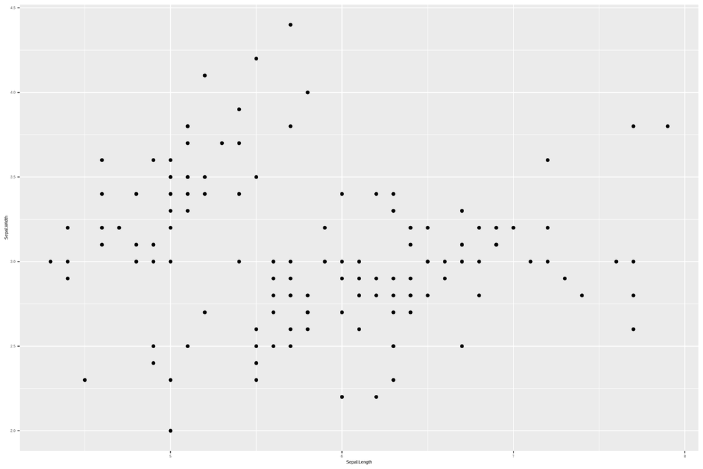

```r
# plot our data
# scatterplot
p = ggplot(iris, aes(x = Sepal.Length, y = Sepal.Width)) +
    geom_point()

p
```

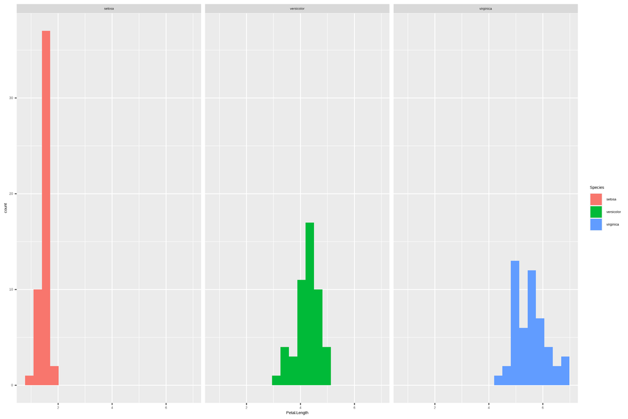

```r
# histogram for temp by month
p2 = ggplot(iris, aes(x = Petal.Length)) +
    geom_histogram(aes(fill = Species), bins = 20) +
    facet_wrap(~ Species)

p2
```

## Writing Functions

All operators in R are functions, for instance `+` is just a special way of calling a function:

```r
# get help for a function
?sum

# get help for the function '+'
?`+`

# check the function definition for `+`
fix(`+`)
```

A function is an operation on input variables ($f(x)), the function can be anything interpretable by R. For example, this is how we can define a function that computes and returns the empirical mean (average) of a numeric vector:

```r
my_mean_function = function(y) {

    n = length(y)
    sum = 0
    for(i in 1:n) sum = sum + y[i]

    mean = sum / n

    return(mean)

}
```

We can now use that function inside R for estimating means on any input vector `y` for which the the operators `+` and `/` are defined.

```r
# generate random vector
x = rnorm(1000, mean = 23.42, sd = 4)

# calculate mean with our function
our_mean = my_mean_function(x)
our_mean
```

```
## [1] 23.51954
```

```r
# compare with R's built in function
mean(x)
```

```
## [1] 23.51954
```